# titanic_survival_zihao_Liu

```python
%matplotlib inline
import time
import pickle
import numpy as np
import pandas as pd
from scipy import stats
import matplotlib.pyplot as plt
import seaborn as sns
from sklearn.model_selection import train_test_split, cross_val_predict
# Importing Classifier Modules
from sklearn.linear_model import LogisticRegression
from sklearn.svm import SVC, LinearSVC
from sklearn.neighbors import KNeighborsClassifier
from sklearn.tree import DecisionTreeClassifier
from sklearn.ensemble import RandomForestClassifier
from sklearn.naive_bayes import GaussianNB
from sklearn.linear_model import Perceptron
from sklearn.linear_model import SGDClassifier
from sklearn.ensemble import GradientBoostingClassifier
from sklearn.neural_network import MLPClassifier
from sklearn.metrics import accuracy_score, precision_score, recall_score, f1_score
import joblib
```

```python
net_id = 'Zihao_Liu'
```

## Step 1:

Preprocess the data. Selection/generation/ transformation of categorical variables, useful variables etc all your discretion.

Read csv file

```python
df = pd.read_csv('train.csv')
N = df.shape[0]
target_col = 'Survived'
df.head()
```

|  | PassengerId | Survived | Pclass | Name | Sex | Age | SibSp | Parch | Ticket | Fare | Cabin | Embarked |
| --- | --- | --- | --- | --- | --- | --- | --- | --- | --- | --- | --- | --- |
| 0 | 1 | 0 | 3 | Braund, Mr. Owen Harris | male | 22.0 | 1 | 0 | A/5 21171 | 7.2500 | NaN | S |
| 1 | 2 | 1 | 1 | Cumings, Mrs. John Bradley (Florence Briggs Th... | female | 38.0 | 1 | 0 | PC 17599 | 71.2833 | C85 | C |
| 2 | 3 | 1 | 3 | Heikkinen, Miss. Laina | female | 26.0 | 0 | 0 | STON/O2. 3101282 | 7.9250 | NaN | S |
| 3 | 4 | 1 | 1 | Futrelle, Mrs. Jacques Heath (Lily May Peel) | female | 35.0 | 1 | 0 | 113803 | 53.1000 | C123 | S |
| 4 | 5 | 0 | 3 | Allen, Mr. William Henry | male | 35.0 | 0 | 0 | 373450 | 8.0500 | NaN | S |

Show basic info of each column

```python
df.info()
```

```
<class 'pandas.core.frame.DataFrame'>
RangeIndex: 891 entries, 0 to 890
Data columns (total 12 columns):
 #   Column       Non-Null Count  Dtype
---  ------       --------------  -----
 0   PassengerId  891 non-null    int64
 1   Survived     891 non-null    int64
 2   Pclass       891 non-null    int64
 3   Name         891 non-null    object
 4   Sex          891 non-null    object
 5   Age          714 non-null    float64
 6   SibSp        891 non-null    int64
 7   Parch        891 non-null    int64
 8   Ticket       891 non-null    object
 9   Fare         891 non-null    float64
 10  Cabin        204 non-null    object
 11  Embarked     889 non-null    object
dtypes: float64(2), int64(5), object(5)
memory usage: 83.7+ KB
```

Show value counts of each column

```python
for col in df.columns:
    print(df[col].value_counts())
```

```
891    1
293    1
304    1
303    1
302    1
      ..
591    1
590    1
589    1
588    1
1      1
Name: PassengerId, Length: 891, dtype: int64
0    549
1    342
Name: Survived, dtype: int64
3    491
1    216
2    184
Name: Pclass, dtype: int64
Ayoub, Miss. Banoura           1
Newell, Mr. Arthur Webster     1
Hansen, Mr. Henry Damsgaard    1
Dodge, Master. Washington      1
Goldsmith, Mr. Frank John      1
                              ..
Hansen, Mr. Claus Peter        1
Uruchurtu, Don. Manuel E       1
Windelov, Mr. Einar            1
Calic, Mr. Jovo                1
Futrelle, Mr. Jacques Heath    1
Name: Name, Length: 891, dtype: int64
male      577
female    314
Name: Sex, dtype: int64
24.00    30
22.00    27
18.00    26
19.00    25
30.00    25
         ..
```

[output cut: 47 more lines]

```
C23 C25 C27    4
B96 B98        4
F2             3
F33            3
              ..
D15            1
C128           1
C86            1
E40            1
T              1
Name: Cabin, Length: 147, dtype: int64
S    644
C    168
Q     77
Name: Embarked, dtype: int64
```

Drop unuseful categorical columns

```python
categorical_cols = ['Sex', 'Embarked']
categorical_cols_to_drop = ['Name', 'Ticket', 'Cabin']

df.drop(columns=categorical_cols_to_drop, inplace=True)
categorical_cols = [col for col in categorical_cols if col not in categorical_cols_to_drop]
df.head()
```

|  | PassengerId | Survived | Pclass | Sex | Age | SibSp | Parch | Fare | Embarked |
| --- | --- | --- | --- | --- | --- | --- | --- | --- | --- |
| 0 | 1 | 0 | 3 | male | 22.0 | 1 | 0 | 7.2500 | S |
| 1 | 2 | 1 | 1 | female | 38.0 | 1 | 0 | 71.2833 | C |
| 2 | 3 | 1 | 3 | female | 26.0 | 0 | 0 | 7.9250 | S |
| 3 | 4 | 1 | 1 | female | 35.0 | 1 | 0 | 53.1000 | S |
| 4 | 5 | 0 | 3 | male | 35.0 | 0 | 0 | 8.0500 | S |

Drop numeric columns with too much missing data. Fill NA cell of numeric columns with mean value

```python
numeric_cols = ['Pclass', 'Age', 'SibSp', 'Parch', 'Fare']
numeric_cols_to_drop = ['PassengerId']
for col in numeric_cols:
    missing_ratio = float(sum(df[col] == np.nan)) / N
    if missing_ratio > 0.3:
        print('Discard Column %s, missing ratio = %.4f' % (col, missing_ratio))
        numeric_cols_to_drop.append(col)
        continue
    value = df[col].mean()
    df[col].fillna(value, inplace=True)
df.drop(columns=numeric_cols_to_drop, inplace=True)
numeric_cols = [col for col in numeric_cols if col not in numeric_cols_to_drop]
df.head()
```

|  | Survived | Pclass | Sex | Age | SibSp | Parch | Fare | Embarked |
| --- | --- | --- | --- | --- | --- | --- | --- | --- |
| 0 | 0 | 3 | male | 22.0 | 1 | 0 | 7.2500 | S |
| 1 | 1 | 1 | female | 38.0 | 1 | 0 | 71.2833 | C |
| 2 | 1 | 3 | female | 26.0 | 0 | 0 | 7.9250 | S |
| 3 | 1 | 1 | female | 35.0 | 1 | 0 | 53.1000 | S |
| 4 | 0 | 3 | male | 35.0 | 0 | 0 | 8.0500 | S |

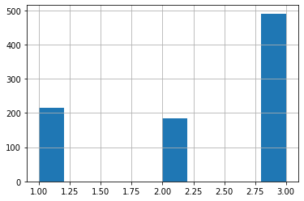

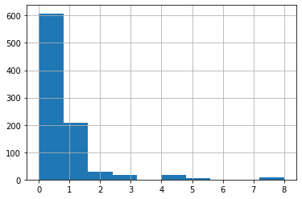

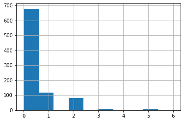

```python
for col in ['Pclass', 'SibSp', 'Parch']:
    plt.figure()
    df[col].hist()
```

Show distribution of conituous numeric colums

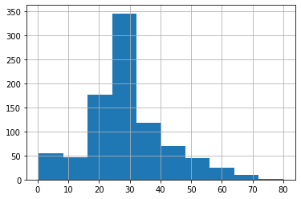

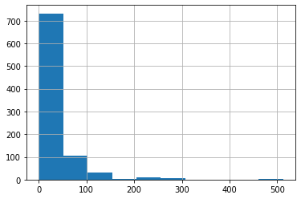

```python
for col in ['Age', 'Fare']:
    plt.figure()
    df[col].hist()
```

Transform categorical columns to one-hot vector features

```python
df = pd.get_dummies(df, columns=categorical_cols)
df.head()
```

|  | Survived | Pclass | Age | SibSp | Parch | Fare | Sex_female | Sex_male | Embarked_C | Embarked_Q | Embarked_S |
| --- | --- | --- | --- | --- | --- | --- | --- | --- | --- | --- | --- |
| 0 | 0 | 3 | 22.0 | 1 | 0 | 7.2500 | 0 | 1 | 0 | 0 | 1 |
| 1 | 1 | 1 | 38.0 | 1 | 0 | 71.2833 | 1 | 0 | 1 | 0 | 0 |
| 2 | 1 | 3 | 26.0 | 0 | 0 | 7.9250 | 1 | 0 | 0 | 0 | 1 |
| 3 | 1 | 1 | 35.0 | 1 | 0 | 53.1000 | 1 | 0 | 0 | 0 | 1 |
| 4 | 0 | 3 | 35.0 | 0 | 0 | 8.0500 | 0 | 1 | 0 | 0 | 1 |

```python
y = df[target_col]
df.drop(columns=[target_col], inplace=True)
df.head()
```

|  | Pclass | Age | SibSp | Parch | Fare | Sex_female | Sex_male | Embarked_C | Embarked_Q | Embarked_S |
| --- | --- | --- | --- | --- | --- | --- | --- | --- | --- | --- |
| 0 | 3 | 22.0 | 1 | 0 | 7.2500 | 0 | 1 | 0 | 0 | 1 |
| 1 | 1 | 38.0 | 1 | 0 | 71.2833 | 1 | 0 | 1 | 0 | 0 |
| 2 | 3 | 26.0 | 0 | 0 | 7.9250 | 1 | 0 | 0 | 0 | 1 |
| 3 | 1 | 35.0 | 1 | 0 | 53.1000 | 1 | 0 | 0 | 0 | 1 |
| 4 | 3 | 35.0 | 0 | 0 | 8.0500 | 0 | 1 | 0 | 0 | 1 |

Make Z-score normalization

```python
df_mean, df_std = df.mean(), df.std()
df = (df - df_mean) / df_std
df.head()
```

|  | Pclass | Age | SibSp | Parch | Fare | Sex_female | Sex_male | Embarked_C | Embarked_Q | Embarked_S |
| --- | --- | --- | --- | --- | --- | --- | --- | --- | --- | --- |
| 0 | 0.826913 | -0.592148 | 0.432550 | -0.473408 | -0.502163 | -0.737281 | 0.737281 | -0.481772 | -0.30739 | 0.618959 |
| 1 | -1.565228 | 0.638430 | 0.432550 | -0.473408 | 0.786404 | 1.354813 | -1.354813 | 2.073341 | -0.30739 | -1.613803 |
| 2 | 0.826913 | -0.284503 | -0.474279 | -0.473408 | -0.488580 | 1.354813 | -1.354813 | -0.481772 | -0.30739 | 0.618959 |
| 3 | -1.565228 | 0.407697 | 0.432550 | -0.473408 | 0.420494 | 1.354813 | -1.354813 | -0.481772 | -0.30739 | 0.618959 |
| 4 | 0.826913 | 0.407697 | -0.474279 | -0.473408 | -0.486064 | -0.737281 | 0.737281 | -0.481772 | -0.30739 | 0.618959 |

## Step 2:

Build your models: Please build classification models in Python to predict the Survived binary status assigned to a passenger. When writing the code associated with each model, please have the first part produce and save the model, followed by a second part that loads and applies the model.

Split dataset to train and validation test

```python
X = df.values
X_train, X_test, y_train, y_test = train_test_split(X, y, test_size=0.1, random_state=0)
```

Define functions for training models

```python
def train(clf_name, X, y):
    """ train model """
    clf = classifiers[clf_name]
    y_hat = cross_val_predict(clf, X, y, cv=10)
    clf.fit(X, y)
    return clf, y_hat


def evaluate(y, y_hat):
    """ evaluate model performance """
    metrics = []
    for metric in [accuracy_score, precision_score, recall_score, f1_score]:
        metrics.append(metric(y, y_hat))
    return metrics


def plot_metric(title, name, metric_index, metrics):
    clfs = list(metrics.keys())
    values = [v[metric_index] for v in metrics.values()]
    indices = list(map(int, np.argsort(values)[::-1]))
    clfs = [clfs[i] for i in indices]
    values = [values[i] for i in indices]
    plt.figure(figsize=(10, 6))
    plt.bar(clfs, values)
    plt.title('%s - %s' % (title, name))
    plt.ylabel(name)
    plt.ylim(min(values) - 0.1, 1.)
    plt.xticks(rotation=45)


def format_metrics(metrics):
    return ', '.join(['%.4f' % m for m in metrics])


def save_model(clf, clf_name):
    joblib.dump(clf, clf_name + '.joblib')

def load_model(clf_name):
    return joblib.load(clf_name + '.joblib')
```

Define a set of models to test.

```python
classifiers = {
    'LogisticRegression': LogisticRegression(),
    'KNN': KNeighborsClassifier(),
    'DecisionTree': DecisionTreeClassifier(),
    'RandomForest': RandomForestClassifier(),
    'GaussianNB': GaussianNB(),
    'SVM-linear': LinearSVC(max_iter=10000),
    'SVM-Polynomial': SVC(kernel='poly'),
    'SVM-Gaussian': SVC(kernel='rbf'),
    'Perceptron': Perceptron(),
    'MLP': MLPClassifier(hidden_layer_sizes=(10,), max_iter=1000),
    'SGD': SGDClassifier(),
    'GradientBoosting': GradientBoostingClassifier(),
}
```

Run 10-fold cross validation and plot results of Accuracy/Precision/Recall/F1-score for each model

```
classifier[LogisticRegression] train_metrics[0.7915, 0.7394, 0.6931, 0.7155] test_metrics[0.8111, 0.7895, 0.7692, 0.7792] time_ms[61]
classifier[KNN] train_metrics[0.8152, 0.7925, 0.6931, 0.7394] test_metrics[0.7556, 0.7576, 0.6410, 0.6944] time_ms[47]
classifier[DecisionTree] train_metrics[0.7753, 0.7071, 0.6931, 0.7000] test_metrics[0.7556, 0.7576, 0.6410, 0.6944] time_ms[23]
classifier[RandomForest] train_metrics[0.8065, 0.7606, 0.7129, 0.7359] test_metrics[0.8222, 0.8485, 0.7179, 0.7778] time_ms[3780]
classifier[GaussianNB] train_metrics[0.7903, 0.7199, 0.7294, 0.7246] test_metrics[0.8111, 0.7750, 0.7949, 0.7848] time_ms[22]
classifier[SVM-linear] train_metrics[0.7990, 0.7536, 0.6964, 0.7238] test_metrics[0.8111, 0.8056, 0.7436, 0.7733] time_ms[878]
classifier[SVM-Polynomial] train_metrics[0.8277, 0.8367, 0.6766, 0.7482] test_metrics[0.7889, 0.8333, 0.6410, 0.7246] time_ms[120]
classifier[SVM-Gaussian] train_metrics[0.8252, 0.8410, 0.6634, 0.7417] test_metrics[0.8111, 0.8929, 0.6410, 0.7463] time_ms[137]
classifier[Perceptron] train_metrics[0.7366, 0.6597, 0.6271, 0.6430] test_metrics[0.6778, 0.5926, 0.8205, 0.6882] time_ms[23]
classifier[MLP] train_metrics[0.8215, 0.8279, 0.6667, 0.7386] test_metrics[0.8111, 0.8438, 0.6923, 0.7606] time_ms[5238]
classifier[SGD] train_metrics[0.7728, 0.6885, 0.7294, 0.7083] test_metrics[0.8111, 0.7895, 0.7692, 0.7792] time_ms[42]
classifier[GradientBoosting] train_metrics[0.8240, 0.8115, 0.6964, 0.7496] test_metrics[0.8222, 0.8966, 0.6667, 0.7647] time_ms[1140]
```

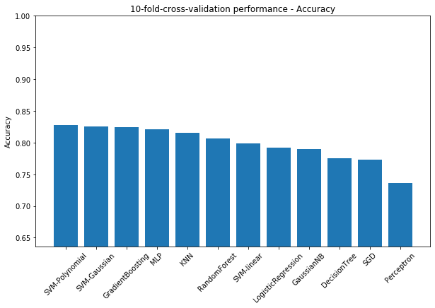

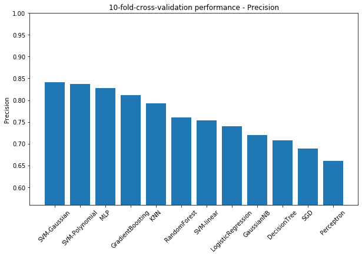

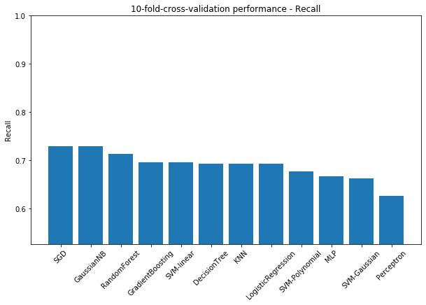

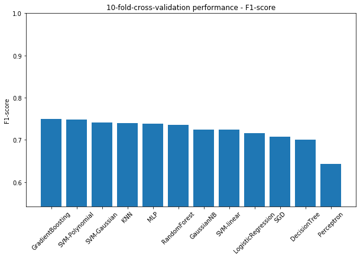

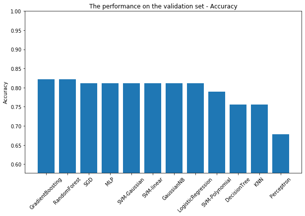

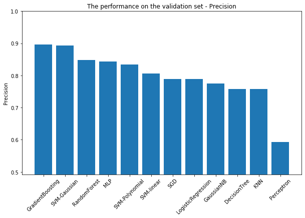

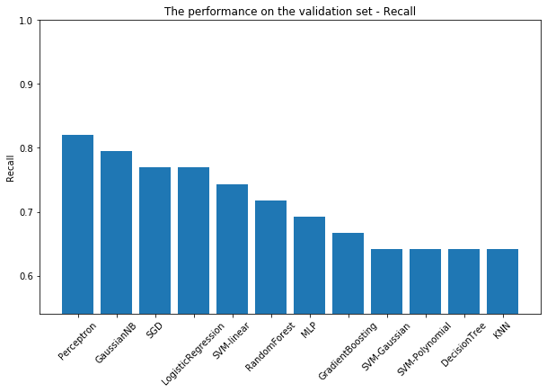

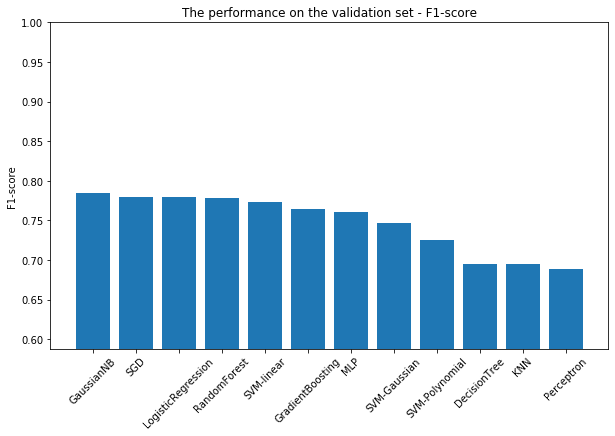

```python
all_train_metrics, all_test_metrics = {}, {}
for clf_name in classifiers:
    start = time.time()
    clf, y_cv_hat = train(clf_name, X_train, y_train)
    save_model(clf, clf_name)
    cost = 1000 * (time.time() - start)
    train_metrics = evaluate(y_train, y_cv_hat)
    test_metrics = evaluate(y_test, clf.predict(X_test))
    print('classifier[%s] train_metrics[%s] test_metrics[%s] time_ms[%d]'
          % (clf_name, format_metrics(train_metrics), format_metrics(test_metrics), cost))
    all_train_metrics[clf_name] = train_metrics
    all_test_metrics[clf_name] = test_metrics

plot_metric('10-fold-cross-validation performance', 'Accuracy', 0, all_train_metrics)
plot_metric('10-fold-cross-validation performance', 'Precision', 1, all_train_metrics)
plot_metric('10-fold-cross-validation performance', 'Recall', 2, all_train_metrics)
plot_metric('10-fold-cross-validation performance', 'F1-score', 3, all_train_metrics)
plot_metric('The performance on the validation set', 'Accuracy', 0, all_test_metrics)
plot_metric('The performance on the validation set', 'Precision', 1, all_test_metrics)
plot_metric('The performance on the validation set', 'Recall', 2, all_test_metrics)
plot_metric('The performance on the validation set', 'F1-score', 3, all_test_metrics)
plt.show()
```

Select the best model by F1-score

```python
metric_index = 3
clfs = list(all_test_metrics.keys())
f1scores = [v[metric_index] for v in all_test_metrics.values()]
indices = list(map(int, np.argsort(f1scores)[::-1]))
clfs = [clfs[i] for i in indices]
f1scores = [f1scores[i] for i in indices]
best_clf_name = clfs[0]
best_clf = load_model(best_clf_name)
print('Best model is %s with F1-score=%.4f' % (best_clf_name, f1scores[0]))
```

```
Best model is GaussianNB with F1-score=0.7848
```

## Step 3:

Test your models using the data found within the "Holdout_testing" file. Save the results of the final model (remember you will only predict the Survived column in holdout test set with your best model results) in a single, separate CSV titled "Titanic Results from" *insert your name or UChicago net ID.

```python
df_test = pd.read_csv('holdout_test.csv')
df_test.head()
```

|  | Survived | PassengerId | Pclass | Name | Sex | Age | SibSp | Parch | Ticket | Fare | Cabin | Embarked |
| --- | --- | --- | --- | --- | --- | --- | --- | --- | --- | --- | --- | --- |
| 0 | NaN | 892 | 3 | Kelly, Mr. James | male | 34.5 | 0 | 0 | 330911 | 7.8292 | NaN | Q |
| 1 | NaN | 893 | 3 | Wilkes, Mrs. James (Ellen Needs) | female | 47.0 | 1 | 0 | 363272 | 7.0000 | NaN | S |
| 2 | NaN | 894 | 2 | Myles, Mr. Thomas Francis | male | 62.0 | 0 | 0 | 240276 | 9.6875 | NaN | Q |
| 3 | NaN | 895 | 3 | Wirz, Mr. Albert | male | 27.0 | 0 | 0 | 315154 | 8.6625 | NaN | S |
| 4 | NaN | 896 | 3 | Hirvonen, Mrs. Alexander (Helga E Lindqvist) | female | 22.0 | 1 | 1 | 3101298 | 12.2875 | NaN | S |

```python
for col in numeric_cols:
    value = df_test[col].mean()
    df_test[col].fillna(value, inplace=True)
```

```python
df_test.drop(columns=categorical_cols_to_drop, inplace=True)
df_test.drop(columns=numeric_cols_to_drop, inplace=True)
df_test.drop(columns=[target_col], inplace=True)
df_test = pd.get_dummies(df_test, columns=categorical_cols)
df_test.head()
```

|  | Pclass | Age | SibSp | Parch | Fare | Sex_female | Sex_male | Embarked_C | Embarked_Q | Embarked_S |
| --- | --- | --- | --- | --- | --- | --- | --- | --- | --- | --- |
| 0 | 3 | 34.5 | 0 | 0 | 7.8292 | 0 | 1 | 0 | 1 | 0 |
| 1 | 3 | 47.0 | 1 | 0 | 7.0000 | 1 | 0 | 0 | 0 | 1 |
| 2 | 2 | 62.0 | 0 | 0 | 9.6875 | 0 | 1 | 0 | 1 | 0 |
| 3 | 3 | 27.0 | 0 | 0 | 8.6625 | 0 | 1 | 0 | 0 | 1 |
| 4 | 3 | 22.0 | 1 | 1 | 12.2875 | 1 | 0 | 0 | 0 | 1 |

```python
df_test = (df_test - df_mean) / df_std
df_test.head()
```

|  | Pclass | Age | SibSp | Parch | Fare | Sex_female | Sex_male | Embarked_C | Embarked_Q | Embarked_S |
| --- | --- | --- | --- | --- | --- | --- | --- | --- | --- | --- |
| 0 | 0.826913 | 0.369241 | -0.474279 | -0.473408 | -0.490508 | -0.737281 | 0.737281 | -0.481772 | 3.249548 | -1.613803 |
| 1 | 0.826913 | 1.330631 | 0.432550 | -0.473408 | -0.507194 | 1.354813 | -1.354813 | -0.481772 | -0.307390 | 0.618959 |
| 2 | -0.369158 | 2.484298 | -0.474279 | -0.473408 | -0.453112 | -0.737281 | 0.737281 | -0.481772 | 3.249548 | -1.613803 |
| 3 | 0.826913 | -0.207592 | -0.474279 | -0.473408 | -0.473739 | -0.737281 | 0.737281 | -0.481772 | -0.307390 | 0.618959 |
| 4 | 0.826913 | -0.592148 | 0.432550 | 0.767199 | -0.400792 | 1.354813 | -1.354813 | -0.481772 | -0.307390 | 0.618959 |

```python
result_file = 'Titanic_Results_from_%s.csv' % net_id
y_test_hat = best_clf.predict(df_test.values)
with open(result_file, 'w') as fout:
    for _y in y_test_hat:
        fout.write('%d\n' % _y)
print('Results are saved in %s' % result_file)
```

[output not shown]

In this study, we try various machine learning method for the classification task, including LogisticRegression, KNN, DecisionTree, RandomForest, GaussianNB, SVM, Perceptron, MLP, SGD and GradientBoosting. Most of them are simple models with nonlinear transformation for features. RandomForest and GradientBoosting are ensemble learning methods which consist of several simple classifiers. Simple classifiers are fast to train and predict, while ensemble learning methods cost more time.